# Question

Consider the $y=\sqrt{x}$ curve shown below. In the context of transforming functions, a very simple function is often called a “parent” function.

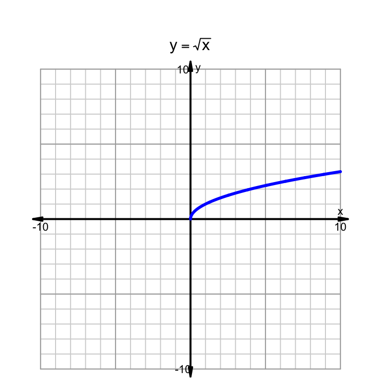

The following 8 graphs are made by translating and reflecting the $y=\sqrt{x}$ curve. So each one is a different daughter function, made by altering the parent function.

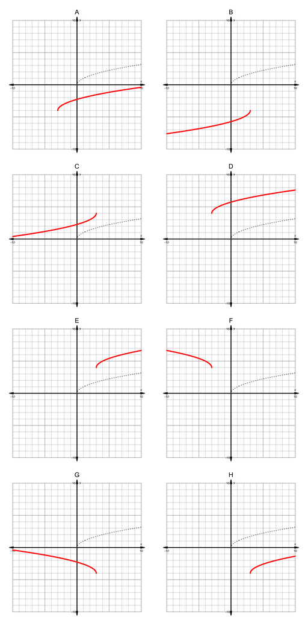

Match the 8 graphs with the equations.

1. Equation $y=-\sqrt{-(x-3)}+4$ matches graph ##ANSWER1##.
2. Equation $y=\sqrt{-(x+3)}+4$ matches graph ##ANSWER2##.
3. Equation $y=\sqrt{x+3}-4$ matches graph ##ANSWER3##.
4. Equation $y=\sqrt{x-3}+4$ matches graph ##ANSWER4##.
5. Equation $y=\sqrt{-(x-3)}-4$ matches graph ##ANSWER5##.
6. Equation $y=\sqrt{x+3}+4$ matches graph ##ANSWER6##.
7. Equation $y=\sqrt{x-3}-4$ matches graph ##ANSWER7##.
8. Equation $y=-\sqrt{-(x-3)}-4$ matches graph ##ANSWER8##.

## Answerlist

- A
- B
- C
- D
- E
- F
- G
- H
- A
- B
- C
- D
- E
- F
- G
- H
- A
- B
- C
- D
- E
- F
- G
- H
- A
- B
- C
- D
- E
- F
- G
- H
- A
- B
- C
- D
- E
- F
- G
- H
- A
- B
- C
- D
- E
- F
- G
- H
- A
- B
- C
- D
- E
- F
- G
- H
- A
- B
- C
- D
- E
- F
- G
- H

# Solution

Let’s call the origin of the parent function the “starting point” of the curve. It is useful to identify where the starting point gets moved to.

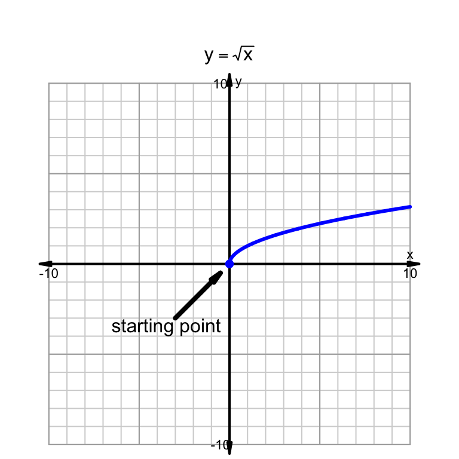

- Operations inside the function (under the radical) change the $x$ values, so they cause horizontal transformations.
- Operations outside the function change the $y$ values, so they cause vertical transformations.
- Addition/subtraction causes a translation (shift). Horizontal shifts are counterintuitive.
- Multiplying by $-1$ causes a reflection.

You can account for all the transformations with 4 parameters ($m$, $n$, $p$, and $q$).

$$y=m\sqrt{n(x+p)}+q$$

- The parameter $m$ is either $-1$ or $1$. If $m=-1$, then the curve is reflected vertically, so the curve goes down from the starting point (instead of up).
- The parameter $n$ is either $-1$ or $1$. If $n=-1$, then the curve is reflected horizontally, so the curve goes left from the starting point (instead of right).
- The parameter $p$ shifts the curve horizontally.
- The parameter $q$ shifts the curve vertically.
- The starting point will be at $(-p,q)$.

### Equation 1

The curve’s equation is $y=-\sqrt{-(x-3)}+4$

Rewrite the equation with explicit parameters.

$y=(-1)\sqrt{(-1)(x+(-3))}+(4)$

So, we can more easily see the values of the parameters.

$$m=-1$$
$$n=-1$$
$$p=-3$$
$$q=4$$
This tells us the new starting point is at $(3,4)$. We also know there is a vertical reflection (because $m=-1$), and there is a horizontal reflection (because $n=-1$). This means, from the starting point, the curve heads left and down. Thus, the correct graph is graph C.

### Equation 2

The curve’s equation is $y=\sqrt{-(x+3)}+4$

Rewrite the equation with explicit parameters.

$y=(1)\sqrt{(-1)(x+(3))}+(4)$

So, we can more easily see the values of the parameters.

$$m=1$$
$$n=-1$$
$$p=3$$
$$q=4$$
This tells us the new starting point is at $(-3,4)$. We also know there is NOT a vertical reflection (because $m=1$), and there is a horizontal reflection (because $n=-1$). This means, from the starting point, the curve heads left and up. Thus, the correct graph is graph F.

### Equation 3

The curve’s equation is $y=\sqrt{x+3}-4$

Rewrite the equation with explicit parameters.

$y=(1)\sqrt{(1)(x+(3))}+(-4)$

So, we can more easily see the values of the parameters.

$$m=1$$
$$n=1$$
$$p=3$$
$$q=-4$$
This tells us the new starting point is at $(-3,-4)$. We also know there is NOT a vertical reflection (because $m=1$), and there is NOT a horizontal reflection (because $n=1$). This means, from the starting point, the curve heads right and up. Thus, the correct graph is graph A.

### Equation 4

The curve’s equation is $y=\sqrt{x-3}+4$

Rewrite the equation with explicit parameters.

$y=(1)\sqrt{(1)(x+(-3))}+(4)$

So, we can more easily see the values of the parameters.

$$m=1$$
$$n=1$$
$$p=-3$$
$$q=4$$
This tells us the new starting point is at $(3,4)$. We also know there is NOT a vertical reflection (because $m=1$), and there is NOT a horizontal reflection (because $n=1$). This means, from the starting point, the curve heads right and up. Thus, the correct graph is graph E.

### Equation 5

The curve’s equation is $y=\sqrt{-(x-3)}-4$

Rewrite the equation with explicit parameters.

$y=(1)\sqrt{(-1)(x+(-3))}+(-4)$

So, we can more easily see the values of the parameters.

$$m=1$$
$$n=-1$$
$$p=-3$$
$$q=-4$$
This tells us the new starting point is at $(3,-4)$. We also know there is NOT a vertical reflection (because $m=1$), and there is a horizontal reflection (because $n=-1$). This means, from the starting point, the curve heads left and up. Thus, the correct graph is graph G.

### Equation 6

The curve’s equation is $y=\sqrt{x+3}+4$

Rewrite the equation with explicit parameters.

$y=(1)\sqrt{(1)(x+(3))}+(4)$

So, we can more easily see the values of the parameters.

$$m=1$$
$$n=1$$
$$p=3$$
$$q=4$$
This tells us the new starting point is at $(-3,4)$. We also know there is NOT a vertical reflection (because $m=1$), and there is NOT a horizontal reflection (because $n=1$). This means, from the starting point, the curve heads right and up. Thus, the correct graph is graph D.

### Equation 7

The curve’s equation is $y=\sqrt{x-3}-4$

Rewrite the equation with explicit parameters.

$y=(1)\sqrt{(1)(x+(-3))}+(-4)$

So, we can more easily see the values of the parameters.

$$m=1$$
$$n=1$$
$$p=-3$$
$$q=-4$$
This tells us the new starting point is at $(3,-4)$. We also know there is NOT a vertical reflection (because $m=1$), and there is NOT a horizontal reflection (because $n=1$). This means, from the starting point, the curve heads right and up. Thus, the correct graph is graph H.

### Equation 8

The curve’s equation is $y=-\sqrt{-(x-3)}-4$

Rewrite the equation with explicit parameters.

$y=(-1)\sqrt{(-1)(x+(-3))}+(-4)$

So, we can more easily see the values of the parameters.

$$m=-1$$
$$n=-1$$
$$p=-3$$
$$q=-4$$
This tells us the new starting point is at $(3,-4)$. We also know there is a vertical reflection (because $m=-1$), and there is a horizontal reflection (because $n=-1$). This means, from the starting point, the curve heads left and down. Thus, the correct graph is graph B.

# Meta-information

extype: cloze exclozetype: schoice|schoice|schoice|schoice|schoice|schoice|schoice|schoice exsolution: 00100000|00000100|10000000|00001000|00000010|00010000|00000001|01000000 exname: translate_flip_sqrt